# Thomas Questions

Thomas Linden

2025-11-29

# Import Dataset

## Question 6

Does who’s in the car relate to acceptance?

```
##
##                0    1
##   Alone     3464 3841
##   Friend(s) 1077 2221
##   Kid(s)     498  508
##   Partner    435  640
```

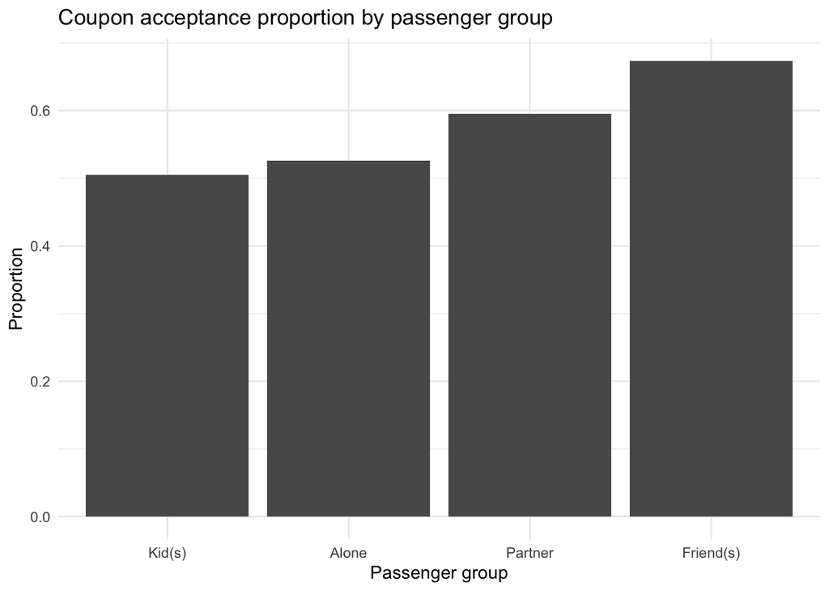

Based on the group-level proportions, we can see the groups that are more likely to accept coupons, however, we need to check whether these differences are statistically significant or could be explained by random variation.

Before performing ANOVA, we check the equal-variance assumption using equavar4test from the testequavar package.

We test-

$H_0: \sigma_{Alone}^2 = \sigma_{Friend(s)}^2 =\sigma_{Kid(s)}^2 =\sigma_{Partner}^2$ (equal variances)

$H_A: \text{At least one group has a different variance.}$

```
## [[1]]
## [1] "Decision: Reject the Null"
##
## $Alpha
## [1] 0.05
##
## $NumberOfBootSamples
## [1] 500
##
## $BootPvalue
## [1] 0.002
```

We test-

$H_0:$ Mean acceptance is equal across all passenger groups.

$H_A:$ At least 1 passenger group has a different mean acceptance.

Method: One-way ANOVA on passenger and acceptance columns.

```
## Analysis of Variance Table
##
## Response: Y
##                         Df  Sum Sq Mean Sq F value    Pr(>F)
## as.factor(passenger)     3   54.47 18.1565  75.307 < 2.2e-16 ***
## Residuals            12680 3057.13  0.2411
## ---
## Signif. codes:  0 '***' 0.001 '**' 0.01 '*' 0.05 '.' 0.1 ' ' 1
```

The ANOVA F-test is highly significant (p < 0.001), indicating that at least one passenger group has a different mean acceptance rate. We therefore follow up with Tukey’s HSD to identify which groups differ.

```
##   Tukey multiple comparisons of means
##     95% family-wise confidence level
##
## Fit: aov(formula = q6.lm)
##
## $`as.factor(passenger)`
##                          diff         lwr         upr     p adj
## Friend(s)-Alone    0.14763420  0.12116728  0.17410112 0.0000000
## Kid(s)-Alone      -0.02083406 -0.06326103  0.02159290 0.5874352
## Partner-Alone      0.06954459  0.02833179  0.11075739 0.0000863
## Kid(s)-Friend(s)  -0.16846827 -0.21390805 -0.12302848 0.0000000
## Partner-Friend(s) -0.07808961 -0.12239786 -0.03378136 0.0000355
## Partner-Kid(s)     0.09037866  0.03503635  0.14572097 0.0001605
```

Since acceptance within each group is modeled as the proportion of 1’s (coupon accepted), the group mean is the estimated probability of acceptance. The Tukey output therefore reports differences in proportions (i.e., differences in average acceptance probabilities), and the lwr and upr columns give 95% confidence intervals for those differences. Positive differences mean the first group in the contrast label has a higher acceptance probability. All pairwise Tukey (studentized range) comparisons are significant at the 0.001 level except Kid(s) − Alone, so given these data we do not have evidence of a difference in acceptance rates between those driving alone and those with kid(s).

Using Tukey’s method to control family-wise error at 5%, we are 95% confident, and estimate that, on average, a person is:

- 12.11% to 17.41% **more likely** to accept a coupon if they are with friend(s) than when they are alone.
- 2.83% to 11.08% **more likely** to accept a coupon if they are with their partner than when they are alone.
- 12.30% to 21.39% **less likely** to accept a coupon if they are with kid(s) than when they are with friend(s).
- 3.38% to 12.24% **less likely** to accept a coupon if they are with their partner than when they are with friend(s).
- 3.50% to 14.57% **more likely** to accept a coupon if they are with their partner than when they are with kid(s)

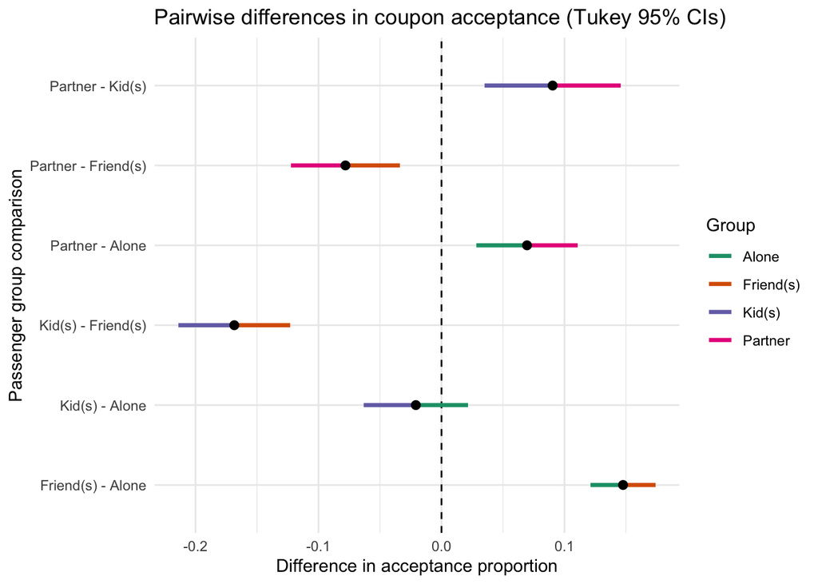

The image above shows Tukey 95% confidence intervals for the difference in coupon‐acceptance proportions for each pair of passenger groups. Each point is the estimated difference in acceptance probability, and the horizontal line is the corresponding 95% confidence interval. The dashed vertical line at 0 represents “no difference”: intervals entirely to the right of 0 indicate that the first group in the label (e.g., Friend(s) – Alone) has a higher acceptance rate; intervals entirely to the left of 0 indicate a lower acceptance rate. For each comparison, the CI segment is colored by the group at that side: the left segment is colored by the less-likely group, and the right segment by the more-likely group.

## Question 8

Do age groups or income bands relate to coupon acceptance?

```r
# Define the desired ordering for age and income factor levels.
age_levels <- c("below21", "21", "26", "31", "36", "41", "46", "50plus")
income_levels <- c(
  "Less than $12500",
  "$12500 - $24999",
  "$25000 - $37499",
  "$37500 - $49999",
  "$50000 - $62499",
  "$62500 - $74999",
  "$75000 - $87499",
  "$87500 - $99999",
  "$100000 or More"
)

# Convert age and income columns to ordered factors with the specified levels.
dataset <- dataset %>%
  mutate(
    age    = factor(age,    levels = age_levels),
    income = factor(income, levels = income_levels)
  )

# --- Counts table: rows = income, columns = age ---

age_income_counts <- dataset %>%
  # Count the number of observations in each Income × Age combination.
  count(income, age, name = "n") %>%
  # Reshape to wide format so each age becomes a column.
  pivot_wider(
    names_from  = age,
    values_from = n,
    values_fill = 0         # Fill empty combinations with 0.
  )

# Display the table of sample sizes by income and age.
kable(
  age_income_counts,
  caption = "Counts by Income (rows) and Age (columns)"
)
```

Counts by Income (rows) and Age (columns)

| income | below21 | 21 | 26 | 31 | 36 | 41 | 46 | 50plus |
| --- | --- | --- | --- | --- | --- | --- | --- | --- |
| Less than $12500 | 175 | 363 | 176 | 44 | 44 | 22 | 44 | 174 |
| $12500 - $24999 | 44 | 496 | 346 | 263 | 183 | 130 | 105 | 264 |
| $25000 - $37499 | 66 | 523 | 392 | 302 | 220 | 196 | 110 | 204 |
| $37500 - $49999 | 44 | 263 | 482 | 310 | 110 | 66 | 133 | 397 |
| $50000 - $62499 | 22 | 374 | 415 | 285 | 154 | 88 | 34 | 287 |
| $62500 - $74999 | 44 | 131 | 171 | 154 | 66 | 187 | 43 | 50 |
| $75000 - $87499 | 0 | 108 | 173 | 197 | 88 | 166 | 42 | 83 |
| $87500 - $99999 | 87 | 132 | 143 | 110 | 176 | 50 | 66 | 131 |
| $100000 or More | 65 | 263 | 261 | 374 | 278 | 188 | 109 | 198 |

Given these sample sizes, the next appropriate part of the analysis is to examine acceptance rates within each Age × Income group.

```r
# --- Proportion table: acceptance rate per Age × Income cell ---

age_income_props <- dataset %>%
  # Compute mean acceptance (proportion of Y = 1) for each Income × Age cell.
  group_by(income, age) %>%
  summarise(prop_Y = mean(Y), .groups = "drop") %>%
  # Reshape to wide format so each age group becomes a column.
  pivot_wider(
    names_from  = age,
    values_from = prop_Y,
    values_fill = NA      # Use NA where a cell has no observations.
  )

# Display the table of acceptance proportions by income and age.
kable(
  age_income_props,
  digits  = 3,
  caption = "Proportion accepted (Y) by Income (rows) and Age (columns)"
)
```

Proportion accepted (Y) by Income (rows) and Age (columns)

| income | below21 | 21 | 26 | 31 | 36 | 41 | 46 | 50plus |
| --- | --- | --- | --- | --- | --- | --- | --- | --- |
| Less than $12500 | 0.577 | 0.623 | 0.676 | 0.636 | 0.386 | 0.636 | 0.705 | 0.471 |
| $12500 - $24999 | 0.705 | 0.589 | 0.581 | 0.589 | 0.557 | 0.562 | 0.600 | 0.511 |
| $25000 - $37499 | 0.439 | 0.566 | 0.656 | 0.563 | 0.636 | 0.587 | 0.573 | 0.608 |
| $37500 - $49999 | 0.659 | 0.601 | 0.645 | 0.494 | 0.545 | 0.591 | 0.556 | 0.489 |
| $50000 - $62499 | 0.727 | 0.631 | 0.578 | 0.681 | 0.558 | 0.648 | 0.529 | 0.491 |
| $62500 - $74999 | 0.795 | 0.542 | 0.439 | 0.468 | 0.500 | 0.561 | 0.581 | 0.600 |
| $75000 - $87499 | NA | 0.519 | 0.376 | 0.421 | 0.534 | 0.596 | 0.619 | 0.458 |
| $87500 - $99999 | 0.655 | 0.682 | 0.559 | 0.545 | 0.466 | 0.480 | 0.621 | 0.321 |
| $100000 or More | 0.754 | 0.616 | 0.678 | 0.532 | 0.500 | 0.532 | 0.495 | 0.626 |

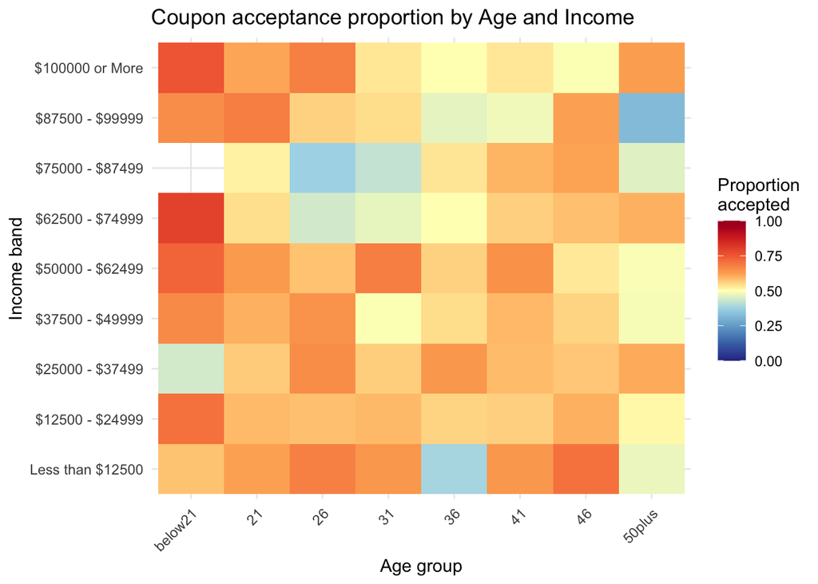

```r
# --- Heatmap of observed acceptance proportions ---

age_income_long <- dataset %>%
  group_by(income, age) %>%
  summarise(prop_Y = mean(Y), .groups = "drop")

ggplot(age_income_long,
       aes(x = age, y = income, fill = prop_Y)) +
  geom_tile() +
  scale_fill_gradientn(
    name   = "Proportion\naccepted",
    limits = c(0, 1),
    colours = c(
      "#313695", "#4575b4", "#74add1", "#abd9e9",
      "#ffffbf", "#fdae61", "#f46d43", "#d73027", "#a50026"
    )
  ) +
  labs(
    x = "Age group",
    y = "Income band",
    title = "Coupon acceptance proportion by Age and Income"
  ) +
  theme_minimal() +
  theme(
    axis.text.x = element_text(angle = 45, hjust = 1)
  )
```

The proportion table and heatmap summarize the observed acceptance rate in each Age × Income cell. Acceptance varies from roughly 0.3 to 0.8, with generally higher rates for younger drivers (below21, 21, 26) and some mid- to lower-income groups, but the pattern is not monotonic in either age or income. These descriptive patterns suggest that both variables may relate to acceptance, but formal testing is needed because the groups differ in size and some cells are relatively small.

Logistic regression is appropriate here because the response is binary (0/1), and the model does not require equal variances or normality assumptions.

```r
# --- Logistic regression with Age × Income interaction ---

# Fit a logistic regression model for coupon acceptance (Y) with
# main effects of age and income plus their interaction.
model_full <- glm(
  Y ~ age * income,
  data   = dataset,
  family = binomial
)

# Likelihood-ratio (Chi-square) tests for age, income, and their interaction.
anova(model_full, test = "Chisq")
```

```
## Analysis of Deviance Table
##
## Model: binomial, link: logit
##
## Response: Y
##
## Terms added sequentially (first to last)
##
##
##            Df Deviance Resid. Df Resid. Dev  Pr(>Chi)
## NULL                       12683      17345
## age         7   63.147     12676      17282 3.542e-11 ***
## income      8   47.923     12668      17234 1.022e-07 ***
## age:income 55  186.950     12613      17047 2.824e-16 ***
## ---
## Signif. codes:  0 '***' 0.001 '**' 0.01 '*' 0.05 '.' 0.1 ' ' 1
```

We fit a logistic regression model predicting coupon acceptance from Age, Income, and their interaction.

$\text{logit}(p) = \beta_0 + \beta_{\text{Age}_i} + \beta_{\text{Income}_j} + \beta_{(\text{Age}_i \space : \space \text{Income}_j)}$

Because the model includes a full interaction, each coefficient represents how acceptance differs from the reference group (below21 and “Less than $12,500”) and how age and income effects change depending on one another.

The Analysis of Deviance shows that Age (χ² = 63.1, p < 0.0001), Income (χ² = 47.9, p < 0.0001), and especially the Age × Income interaction (χ² = 187.0, p < 0.0001) all significantly improve model fit. This indicates that neither age nor income acts independently—the effect of income depends on age, and the effect of age depends on income.

One interaction coefficient was not estimable due to an empty Age × Income cell, which is consistent with the count table and does not affect the rest of the model.

Overall, the interaction model fits significantly better than the null model, although acceptance is clearly influenced by additional variables not included here. The next step is to visualize model-based predicted probabilities for each Age × Income combination.

```r
# ---- Model-based predictions using predict() ----

# Build grid of all Age x Income combinations.
new_grid <- expand.grid(
  age    = levels(dataset$age),
  income = levels(dataset$income)
)

# Predict on the logit scale with standard errors.
pred_link <- predict(
  model_full,
  newdata = new_grid,
  type   = "link",
  se.fit = TRUE
)
```

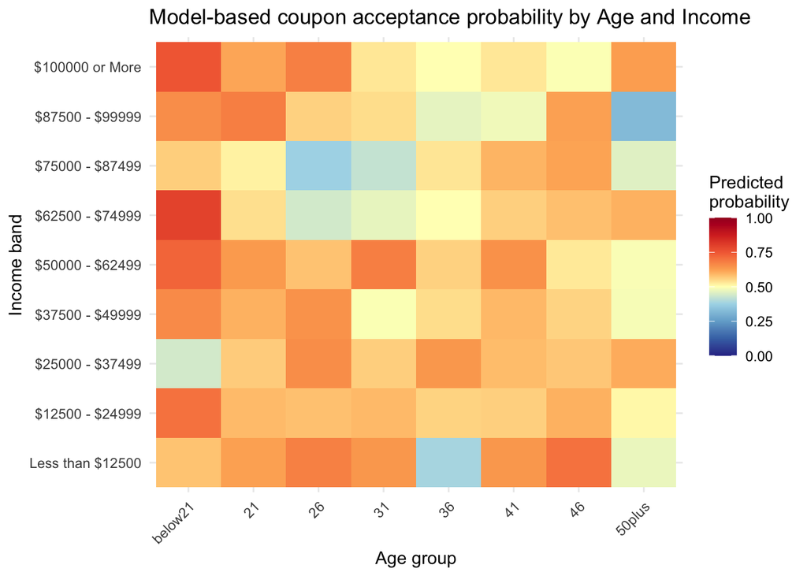

```r
# Transform to predicted probabilities and 95% CIs.
new_grid <- new_grid %>%
  mutate(
    fit_link = pred_link$fit,
    se_link  = pred_link$se.fit,
    prob     = plogis(fit_link),                         # predicted probability
    lower    = plogis(fit_link - 1.96 * se_link),        # 95% CI lower
    upper    = plogis(fit_link + 1.96 * se_link)         # 95% CI upper
  )

# ---- Heatmap of predicted acceptance probabilities ----

ggplot(new_grid,
       aes(x = age, y = income, fill = prob)) +
  geom_tile() +
  scale_fill_gradientn(
    name   = "Predicted\nprobability",
    limits = c(0, 1),
    colours = c(
      "#313695", "#4575b4", "#74add1", "#abd9e9",
      "#ffffbf", "#fdae61", "#f46d43", "#d73027", "#a50026"
    )
  ) +
  labs(
    x = "Age group",
    y = "Income band",
    title = "Model-based coupon acceptance probability by Age and Income"
  ) +
  theme_minimal() +
  theme(
    axis.text.x = element_text(angle = 45, hjust = 1)
  )
```